# Modelling excess covid death in France

# Preliminaries

*import the packages that we need*

```r
library(tidyverse)
library(lubridate)
library(aweek)
library(gridExtra)
library(ggplot2)
```

## Function to download OWID data

*This function download the OWID data of the specified country*

```r
download_owid_data <- function(country_code) {
  if (country_code == "France") {
    owid_url <- "https://raw.githubusercontent.com/owid/covid-19-data/master/public/data/jhu/new_deaths.csv"
  } else {
    owid_url <- "https://raw.githubusercontent.com/owid/covid-19-data/master/public/data/jhu/new_deaths.csv"
  }

  owid_data <- read_csv(owid_url) %>%
    select(date, !!country_code) %>%
    mutate(!!country_code := ifelse(is.na(!!rlang::sym(country_code)), 0, !!rlang::sym(country_code))) %>%
    mutate(cdeath2 = cumsum(!!rlang::sym(country_code))) %>%
    rename(deaths2 = !!country_code)

  return(owid_data)
}
```

```r
owid_data_FRA <- download_owid_data("France")
```

## Function to download JHU data

*This function download the JHU data of the specified country*

```r
download_jhu_data <- function(country_name) {
  jhu_url <- "https://raw.githubusercontent.com/CSSEGISandData/COVID-19/master/csse_covid_19_data/csse_covid_19_time_series/time_series_covid19_deaths_global.csv"
  jhu_data <- read_csv(jhu_url)

  jhu_data <- jhu_data %>%
    rename(Country = `Country/Region`)

  jhu_data <- jhu_data %>%
    filter(Country == country_name)

  jhu_data <- jhu_data %>%
    select(-Lat, -Long)

  jhu_data <- jhu_data %>%
    pivot_longer(cols = -(1:2), names_to = "date", values_to = "cdeaths") %>%
    mutate(date = as.Date(date, tryFormats = c("%m/%d/%Y"))) %>%
    mutate(date = date + dyears(2000) - ddays(15)) %>%
    group_by(date) %>%
    summarise(cdeaths = sum(cdeaths)) %>%
    ungroup() %>%
    mutate(death = cdeaths - lag(cdeaths))

  return(jhu_data)
}
```

```r
jhu_data_France <- download_jhu_data("France")
```

## Daily deaths for JHU and OWID

*This code compute the daily deaths for OWID and JHU data frames and plot a graphic*

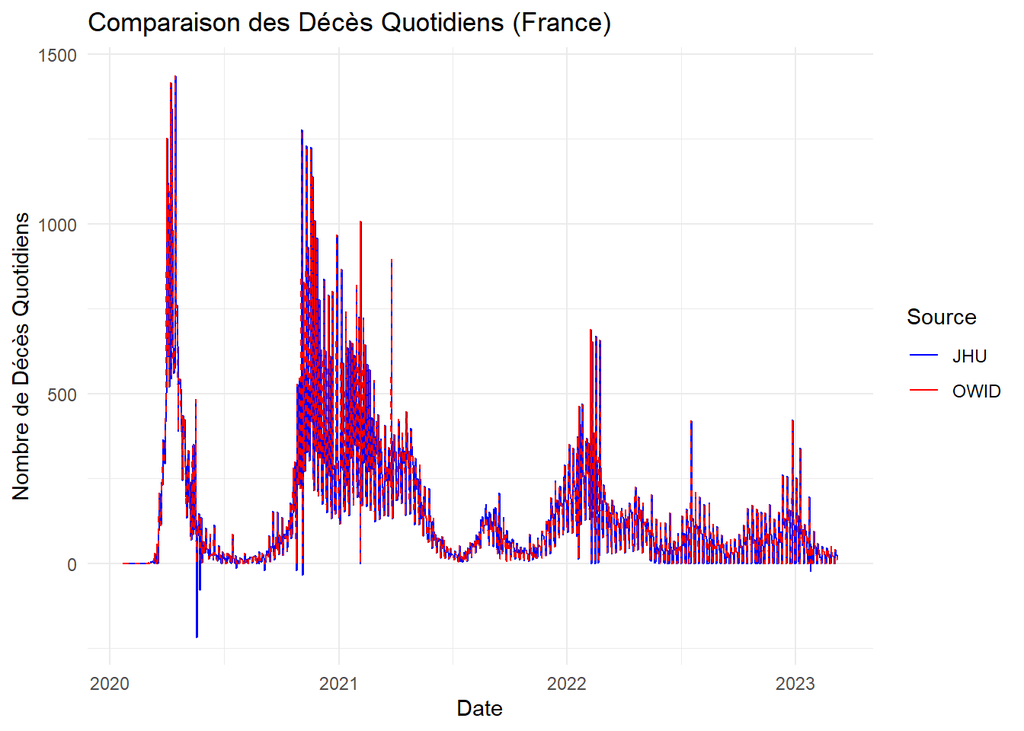

```r
daily_deaths_JHU <- jhu_data_France$death

daily_deaths_OWID <- owid_data_FRA$deaths2

comparison_data <- data.frame(
  Date = jhu_data_France$date,
  JHU_Daily_Deaths = daily_deaths_JHU,
  OWID_Daily_Deaths = daily_deaths_OWID
)

ggplot(comparison_data, aes(x = Date)) +
  geom_line(aes(y = JHU_Daily_Deaths, color = "JHU"), linetype = "solid") +
  geom_line(aes(y = OWID_Daily_Deaths, color = "OWID"), linetype = "dashed") +
  labs(title = "Comparaison des Décès Quotidiens (France)",
       y = "Nombre de Décès Quotidiens",
       color = "Source") +
  scale_color_manual(values = c("JHU" = "blue", "OWID" = "red")) +
  theme_minimal()
```

## Cumuluative deaths for JHU and OWID data

*This code compute the cumulative deaths for OWID and JHU data frames and plot a graphic*

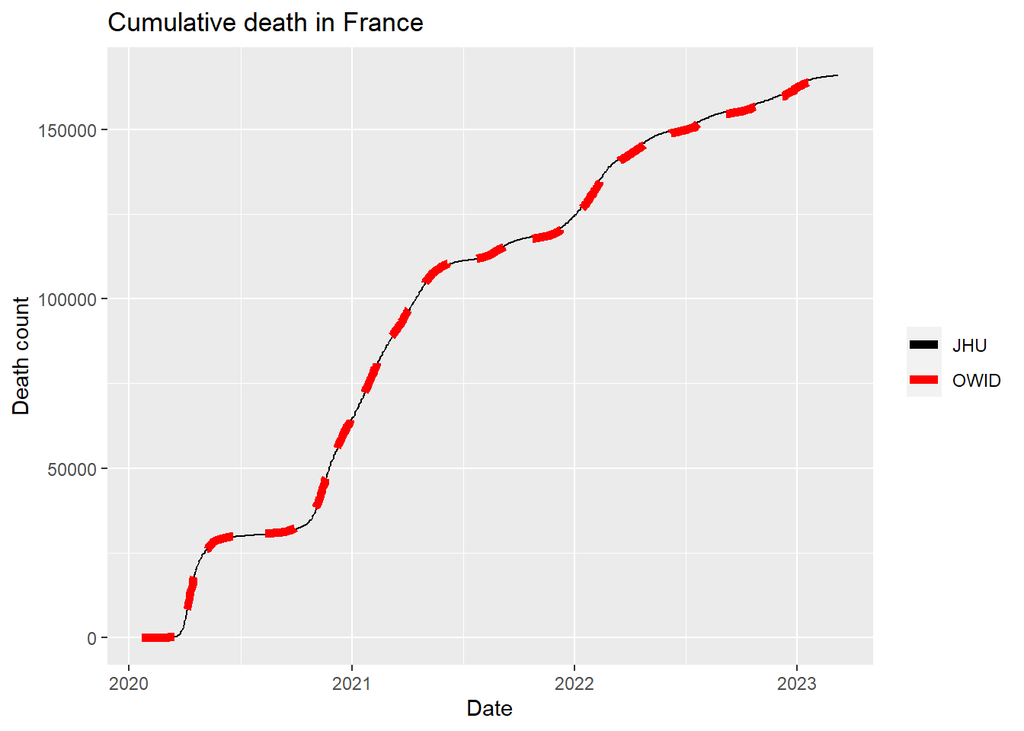

```r
cumulative_deaths_JHU <- jhu_data_France$cdeaths

cumulative_deaths_OWID <- owid_data_FRA$cdeath2

comparison_data_cumulative <- data.frame(
  Date = jhu_data_France$date,
  JHU_Cumulative_Deaths = cumulative_deaths_JHU,
  OWID_Cumulative_Deaths = cumulative_deaths_OWID
)

ggplot(comparison_data_cumulative, aes(x = Date)) +
  geom_line(aes(y = JHU_Cumulative_Deaths, color = "JHU"), linetype = "solid") +
  geom_line(aes(y = OWID_Cumulative_Deaths, color = "OWID"), lty = 2, lwd = 2) +
  labs(title = "Cumulative death in France",
       y = "Death count",
       color = "Source") +
  scale_color_manual(values = c("JHU" = "black", "OWID" = "red")) +
  guides(color = guide_legend(title = NULL))
```

## Function to compute the population

*This function compute the population of a country with the OWID covid dataset*

```r
get_population_from_owid <- function(country_name) {
  owid_population_url <- "https://raw.githubusercontent.com/owid/covid-19-data/master/public/data/owid-covid-data.csv"
  owid_population_data <- owid_population_url %>%
    url() %>%
    read_csv()

  population <- owid_population_data %>%
    filter(location == country_name) %>%
    select(population)

  return(population)
}
```

```r
population_France <- get_population_from_owid("France")
```

## Function to download mortality data

*This function download the mortality data set*

```r
download_mortality_data <- function(country_iso3c) {
  world_mort_url <- "https://raw.githubusercontent.com/akarlinsky/world_mortality/main/world_mortality.csv"

  mortality_data <- world_mort_url %>%
    url() %>%
    read_csv()

  country_mortality_data <- mortality_data %>%
    filter(iso3c == country_iso3c)

  return(country_mortality_data)
}
```

```r
mortality_France <- download_mortality_data("FRA")
mortality_France %>%
    select(-c(iso3c,country_name,time_unit)) %>%
    rename(mortality=deaths, week=time) ->
    mortality_France
```

## Weekly deaths for France

*We compute weekly deaths for France*

```r
owid_data_FRA <- owid_data_FRA %>%
  mutate(date = as.Date(date))

owid_data_weekly <- owid_data_FRA %>%
  group_by(year = lubridate::year(date), week = lubridate::isoweek(date)) %>%
  summarize(deaths = sum(deaths2))
```

```r
owid_data_weekly
```

```
## # A tibble: 166 × 3
## # Groups:   year [4]
##     year  week deaths
##    <dbl> <dbl>  <dbl>
##  1  2020     4      0
##  2  2020     5      0
##  3  2020     6      0
##  4  2020     7      1
##  5  2020     8      0
##  6  2020     9      1
##  7  2020    10     17
##  8  2020    11     72
##  9  2020    12    585
## 10  2020    13   1932
## # ℹ 156 more rows
```

```r
owid_data_weekly <- inner_join(owid_data_weekly,
                                 mortality_France, by=c("year", "week") )

owid_data_weekly %>%
    mutate(start_date = get_date(week=week,year=year)) ->
    owid_data_weekly

tail(owid_data_weekly)
```

```
## # A tibble: 6 × 5
## # Groups:   year [1]
##    year  week deaths mortality start_date
##   <dbl> <dbl>  <dbl>     <dbl> <date>
## 1  2023     5    286     12988 2023-01-30
## 2  2023     6    171     12903 2023-02-06
## 3  2023     7    175     12683 2023-02-13
## 4  2023     8    165     12511 2023-02-20
## 5  2023     9    153     12478 2023-02-27
## 6  2023    10    105     12687 2023-03-06
```

```r
population_France_constante <- unique(population_France$population)

owid_data_weekly <- owid_data_weekly %>%
  mutate(deaths_per_100k = (deaths / population_France_constante) * 100000)

tail(owid_data_weekly)
```

```
## # A tibble: 6 × 6
## # Groups:   year [1]
##    year  week deaths mortality start_date deaths_per_100k
##   <dbl> <dbl>  <dbl>     <dbl> <date>               <dbl>
## 1  2023     5    286     12988 2023-01-30           0.422
## 2  2023     6    171     12903 2023-02-06           0.252
## 3  2023     7    175     12683 2023-02-13           0.258
## 4  2023     8    165     12511 2023-02-20           0.243
## 5  2023     9    153     12478 2023-02-27           0.226
## 6  2023    10    105     12687 2023-03-06           0.155
```

*We have created a new object for the population, since it is constant and makes calculations easier* *So we can plot two graphs*

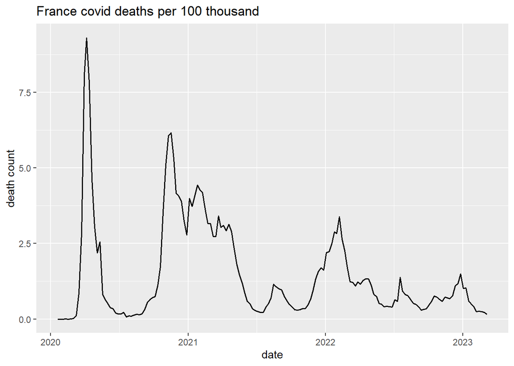

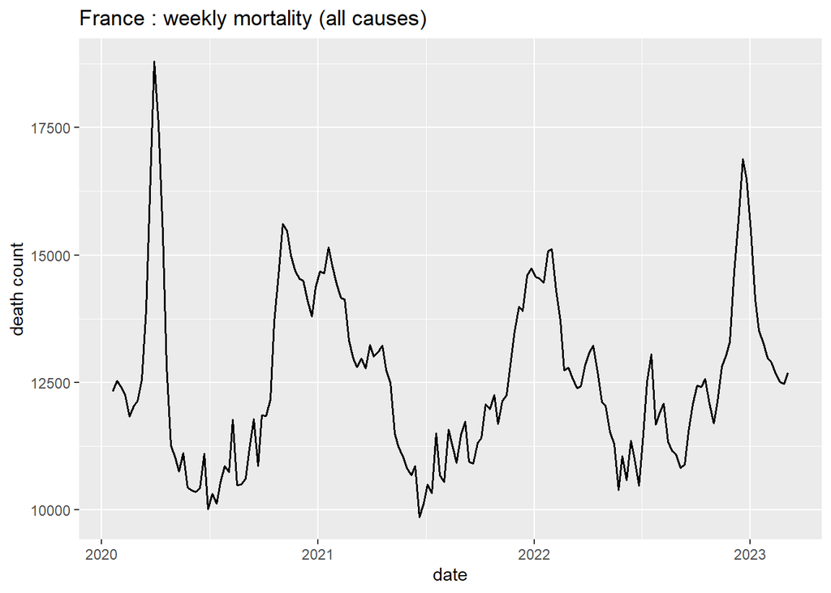

```r
p1 <- ggplot(owid_data_weekly, aes(x=start_date))+
  geom_line(aes(y = deaths_per_100k), lwd = 0.7)+
  ggtitle("France covid deaths per 100 thousand")+
  labs(x="date", y="death count")

p2 <- ggplot(owid_data_weekly, aes(x=start_date))+
  geom_line(aes(y = mortality), lwd = 0.7) +
  ggtitle("France : weekly mortality (all causes)")+
  labs(x="date", y="death count")

print(p1)
print(p2)
```

## Function to compute excess deaths

*We use an OLS model to estimate excess deaths in France. The model is modf <- mortality ~ year + factor(week)*

```r
mortality_France <- mortality_France %>%
  mutate(start_date = as.Date(paste(year, "01-01"), format = "%Y %d-%m") + weeks(week - 1))
```

```r
get_excess_deaths <- function(mortality_data, start_date = "2020-03-01") {
  modf <- mortality ~ year + factor(week)

  ts_model <- lm(modf, data = mortality_data, subset = start_date <= "2020-03-01")

  mortality_data_filtered <- mortality_data[mortality_data$start_date >= start_date, ]

  predicted_deaths <- predict(ts_model, newdata = mortality_data_filtered)

  excess_deaths <- mortality_data_filtered$mortality - predicted_deaths

  excess_deaths_per_100k <- (excess_deaths / population_France_constante) * 100000

  mortality_data_filtered$excess_deaths <- excess_deaths
  mortality_data_filtered$excess_deaths_per_100k <- excess_deaths_per_100k

  return(mortality_data_filtered)
}
```

```r
mortality_France_with_excess <- get_excess_deaths(mortality_France)
```

*So we can plot two graphs to illustrate*

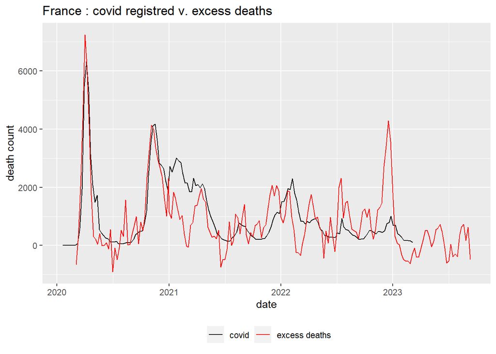

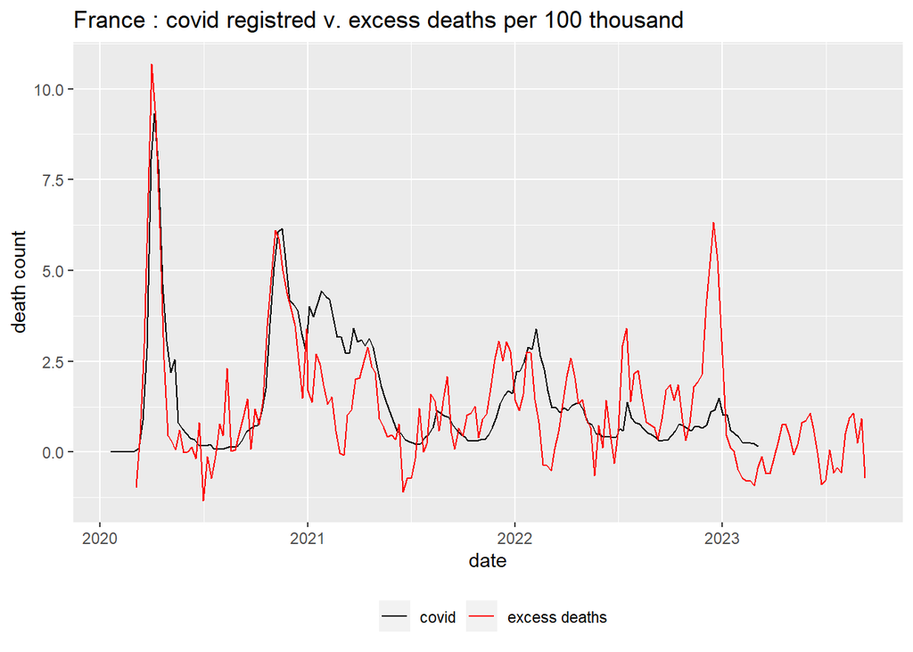

```r
p3 <- ggplot() +
  geom_line(data = owid_data_weekly, aes(x = start_date, y = deaths, color = "covid")) +
  geom_line(data = mortality_France_with_excess, aes(x = start_date, y = excess_deaths, color = "excess deaths")) +
  labs(
    title = "France : covid registred v. excess deaths",
    x = "date",
    y = "death count"
  ) +
  scale_color_manual(values = c("covid" = "black", "excess deaths" = "red"))+
  guides(color = guide_legend(title = NULL)) +
  theme(legend.position = "bottom")

p4 <- ggplot() +
  geom_line(data = owid_data_weekly, aes(x = start_date, y = deaths_per_100k, color = "covid")) +
  geom_line(data = mortality_France_with_excess, aes(x = start_date, y = excess_deaths_per_100k, color = "excess deaths")) +
  labs(
    title = "France : covid registred v. excess deaths per 100 thousand",
    x = "date",
    y = "death count"
  ) +
  scale_color_manual(values = c("covid" = "black", "excess deaths" = "red")) +
  guides(color = guide_legend(title = NULL)) +
  theme(legend.position = "bottom")

print(p3)
print(p4)
```

# Country-level analysis

*We now turn our attention to Germany, and apply our functions and have graphs and be able to compare France and Germany*

*We use previous functions to get all the data that we need*

```r
owid_data_GER <- download_owid_data("Germany")
mortality_Germany <- download_mortality_data("DEU")
population_Germany <- get_population_from_owid("Germany")
population_Germany_constante <- unique(population_Germany$population)
```

*Now we do some arrangements in the data*

```r
owid_data_GER <- owid_data_GER %>%
  mutate(date = as.Date(date))

owid_data_GER_weekly <- owid_data_GER %>%
  group_by(year = lubridate::year(date), week = lubridate::isoweek(date)) %>%
  summarize(deaths = sum(deaths2))
```

```r
owid_data_GER_weekly
```

```
## # A tibble: 166 × 3
## # Groups:   year [4]
##     year  week deaths
##    <dbl> <dbl>  <dbl>
##  1  2020     4      0
##  2  2020     5      0
##  3  2020     6      0
##  4  2020     7      0
##  5  2020     8      0
##  6  2020     9      0
##  7  2020    10      0
##  8  2020    11     12
##  9  2020    12     44
## 10  2020    13    334
## # ℹ 156 more rows
```

```r
mortality_Germany <- mortality_Germany %>%
  select(-iso3c, -country_name, -time_unit)
```

```r
mortality_Germany <- mortality_Germany %>%
  rename(week = time)
```

```r
mortality_Germany <- mortality_Germany %>%
  rename(mortality = deaths)
```

```r
owid_data_GER_weekly <- owid_data_GER_weekly %>%
  mutate(start_date = as.Date(paste(year, "01-01"), format = "%Y %d-%m") + weeks(week - 1))
```

```r
mortality_Germany <- mortality_Germany %>%
  mutate(start_date = as.Date(paste(year, "01-01"), format = "%Y %d-%m") + weeks(week - 1))
```

*So now we can use this functions*

```r
mortality_Germany_with_excess <- get_excess_deaths(mortality_Germany)
```

*And we can plot some graphs*

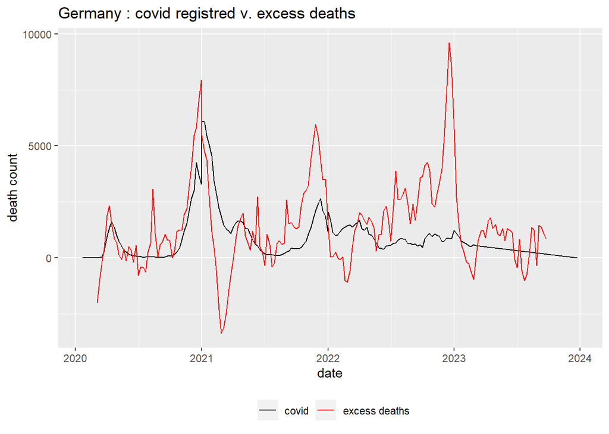

```r
p5 <- ggplot() +
  geom_line(data = owid_data_GER_weekly, aes(x = start_date, y = deaths, color = "covid")) +
  geom_line(data = mortality_Germany_with_excess, aes(x = start_date, y = excess_deaths, color = "excess deaths")) +
  labs(
    title = "Germany : covid registred v. excess deaths",
    x = "date",
    y = "death count"
  ) +
  scale_color_manual(values = c("covid" = "black", "excess deaths" ="red")) +
  guides(color = guide_legend(title = NULL)) +
  theme(legend.position = "bottom")

print(p5)
```

# Comparison: excess deaths per 100k

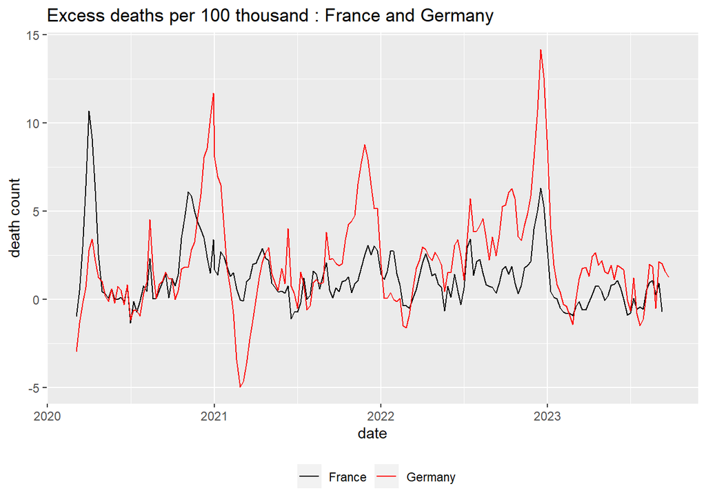

```r
p6 <- ggplot() +
  geom_line(data = mortality_France_with_excess, aes(x = start_date, y = excess_deaths_per_100k, color = "France")) +
  geom_line(data = mortality_Germany_with_excess, aes(x = start_date, y = excess_deaths_per_100k, color = "Germany")) +
  labs(
    title = "Excess deaths per 100 thousand : France and Germany",
    x = "date",
    y = "death count"
  ) +
  scale_color_manual(values = c("France" = "black", "Germany" ="red")) +
  guides(color = guide_legend(title = NULL)) +
  theme(legend.position = "bottom")
print(p6)
```